# COMPSCI 369 Notebook | Assignment 1

- **Name:** *Sabaoon Raza Khan*
- **ID:** 983957824
- **UPI:** skha787@aucklanduni.ac.nz

### Problem 0: Working with Jupyter notebooks

**(a)** It is easy to type maths in markdown, it is like Latex. We can write inline maths like $f(x) = x^2$ or displayed maths such as

$$\mathbf{a} = \left[\begin{array} {rrr} 1 \\ 2 \\ 3 \end{array}\right] . $$

**(b)** Embedding UOA image, so it's included at distribution.

[figure not shown]

```python
from IPython.display import Image
Image(filename="UOA.png")
```

**(c)** Plotting the function $f(x) = x^2 − 5$ for $−10 < x < 10$. *(Code + Output)*

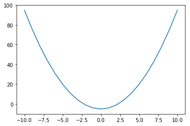

```python
import matplotlib.pyplot as plt

a = [] # X-values to plot
b = [] # Y-values to plot

for x in range(-10, 11, 1):
    y = x**2 - 5
    a.append(x)
    b.append(y)
    # Incrementing x by 1
    # Python Range (-10, 11) -> Actually [-10, 10]

fig = plt.figure()
axes = fig.add_subplot(111) #1x1 grid
axes.plot(a,b)
plt.show()
```

### Problem 1: Root finding

**(a) & (b)** Newton's Method to find roots of equations using the following formula:

$$x_{i+1} = x_{i} - \frac{f(x_{i})}{f'(x_{i})}$$

Start at $x=0$, until $|x_{i} - x_{i-1}| \leqslant 0.0001$

- $f(x) = 20x^3 − 50x^2 + 3x + 20$  
  $f'(x) = 60x^2 - 100x + 3$

```python
from math import exp, log

# Function to find roots of
def f(x):
    return 20*x**3 - 50*x**2 + 3*x + 20

# Derivation of function
def df(x):
    return 60*x**2 - 100*x + 3

def main():
    # Given parameters
    initial = 0
    tolerance = 0.0001

    # Initialising iteration counter
    value = 0

    # Using to compute |x_{i} − x_{i−1}|
    next = initial - (f(initial) / df(initial))
    diff = abs(next - initial)

    # Printing initial two lines of output
    print("Iteration    " + "Xi         " + "f(Xi)")
    print("0           ", '{:.5f}'.format(initial), "  ", '{:.5f}'.format(f(initial))) #Formatting floats to 5 decimal places

    # Main algorithm for newton's method
    while not (diff <= tolerance):
        value += 1
        next = initial - (f(initial) / df(initial))
        diff = abs(next - initial)
        initial = next # Swapping values
        if not (diff <= tolerance):
            print(value, "          ", '{:.5f}'.format(next), "  ", '{:.5f}'.format(f(next)))
main()
```

```
Iteration    Xi         f(Xi)
0            0.00000    20.00000
1            -6.66667    -8148.14815
2            -4.22442    -2392.71654
3            -2.62521    -694.30611
4            -1.60270    -195.57706
5            -0.98650    -50.81939
6            -0.66896    -10.36946
7            -0.56178    -1.01087
8            -0.54884    -0.01398
9            -0.54865    -0.00000
```

- $g(x) = exp(0.5x) − exp(0.6x) + 4$  
  $g'(x) = 0.5exp(0.5x) - 0.6exp(0.6x)$

```python
from math import exp, log

# Function to find roots of
def f(x):
    return exp(0.5*x) - exp(0.6*x) + 4

# Derivation of function
def df(x):
    return 0.5*exp(0.5*x) - 0.6*exp(0.6*x)

def main():
    # Given parameters
    initial = 0
    tolerance = 0.0001

    # Initialising iteration counter
    value = 0

    # Using to compute |x_{i} − x_{i−1}|
    next = initial - (f(initial) / df(initial))
    diff = abs(next - initial)

    # Printing initial two lines of output
    print("Iteration    " + "Xi         " + "f(Xi)")
    print("0           ", '{:.5f}'.format(initial), "  ", '{:.5f}'.format(f(initial))) #Formatting floats to 5 decimal places

    # Main algorithm for newton's method
    while not (diff <= tolerance):
        value += 1
        next = initial - (f(initial) / df(initial))
        diff = abs(next - initial)
        initial = next  # Swapping values
        if not (diff <= tolerance):
            print(value, "          ", '{:.5f}'.format(next), "  ", '{:.5f}'.format(f(next)))
main()
```

```
Iteration    Xi         f(Xi)
0            0.00000    4.00000
1            40.00000    -26003956930.43377
2            38.33850    -9563661115.39857
3            36.67795    -3517112274.01410
4            35.01853    -1293365182.09137
5            33.36045    -475580028.81207
6            31.70397    -174858613.56926
7            30.04939    -64284081.49344
8            28.39708    -23629961.70956
9            26.74748    -8684675.03663
10            25.10112    -3191242.94136
11            23.45867    -1172364.37610
12            21.82092    -430563.30490
13            20.18885    -158070.37033
14            18.56371    -58004.09710
15            16.94705    -21271.50435
16            15.34092    -7794.19264
17            13.74809    -2852.39540
18            12.17264    -1041.81392
19            10.62109    -379.15011
20            9.10532    -136.96437
21            7.64929    -48.63590
22            6.30439    -16.54423
23            5.17626    -5.02126
24            4.43163    -1.11281
25            4.15235    -0.10439
26            4.12033    -0.00120
27            4.11995    -0.00000
```

**(c)** Using bisection method to find roots of:

$$f(x) = 20x^3 − 50x^2 + 3x + 20$$

Given interval -> {(a, b) = (0, 1)}

```python
# Function to find roots of
def f(x):
    return (20*x**3 - 50*x**2 + 3*x + 20)

# Given values of a and b, where function f is defined.
a = 0.0
b = 1.0

# Given tolerance
tolerance = 0.0001

# Printing initial line of output
print("Iteration", "     ", "a", "         ", "b", "        ", "f(c)")

# Bisection method function
def bisection(a, b, f, tolerance):
    iter = 0 # Iteration counter
    max = 50 # Ensuring algorithm doesn't run too long
    while iter < max:
        midpt = (a + b)/2 # Calculating mid-point
        func_mid = f(midpt)
        result = print(iter, "          ", '{:.5f}'.format(a), "   ", '{:.5f}'.format(b), "   ", '{:.5f}'.format(func_mid))
        if (abs(b - a) < tolerance):
            break
        iter += 1
        if f(a) * func_mid > 0: # Checking for signs (+ or -)
            a = midpt
        else:
            b = midpt
    return result

bisection(a, b, f, tolerance)
```

```
Iteration       a           b          f(c)
0            0.00000     1.00000     11.50000
1            0.50000     1.00000     2.56250
2            0.75000     1.00000     -2.25781
3            0.75000     0.87500     0.15723
4            0.81250     0.87500     -1.05090
5            0.81250     0.84375     -0.44676
6            0.81250     0.82812     -0.14472
7            0.81250     0.82031     0.00627
8            0.81641     0.82031     -0.06922
9            0.81641     0.81836     -0.03148
10            0.81641     0.81738     -0.01260
11            0.81641     0.81689     -0.00317
12            0.81641     0.81665     0.00155
13            0.81653     0.81665     -0.00081
14            0.81653     0.81659     0.00037
```

**Comment:** The speed of convergence for Newton's method for the same function is comparatively faster than the bisection method executed. The number of iterations using Newton's method are fewer than those needed using the bisection method.

### Problem 2: SVD based data compression

#### Reading and Displaying PGM file

**(a)** Including a 120px x 100px PNG image, converted to grayscale and PGM file.  
Performing SVD on image for compression & illustrating results by components $A = UDV^{T}$

```
A =
```

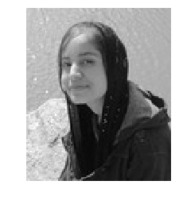

```
U =
```

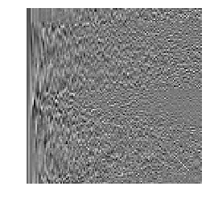

```
D =
```

[figure not shown]

```
Vt =
```

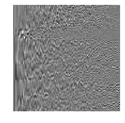

```python
from matplotlib import pyplot
import re
import numpy
import numpy.linalg
import matplotlib.pyplot as plt


def read_pgm(filename, byteorder='>'):
    """Return image data from a raw PGM file as numpy array.

    Format specification: http://netpbm.sourceforge.net/doc/pgm.html

    """
    with open(filename, 'rb') as f:
        buffer = f.read()
    try:
        header, width, height, maxval = re.search(
            b"(^P5\s(?:\s*#.*[\r\n])*"
            b"(\d+)\s(?:\s*#.*[\r\n])*"
            b"(\d+)\s(?:\s*#.*[\r\n])*"
            b"(\d+)\s(?:\s*#.*[\r\n]\s)*)", buffer).groups()
    except AttributeError:
        raise ValueError("Not a raw PGM file: '%s'" % filename)
    return numpy.frombuffer(buffer,
                            dtype='u1' if int(maxval) < 256 else byteorder+'u2',
                            count=int(width)*int(height),
                            offset=len(header)
                            ).reshape((int(height), int(width)))


def display_pgm(array):
    pyplot.imshow(array, pyplot.cm.gray)
    pyplot.axis('off')
    pyplot.show()

image = read_pgm("sabaoon.pgm")

# Displaying original image
print("\nA =")
display_pgm(image)

# Performing the SVD, A = UDV^T of the facial image:
U, D, V = numpy.linalg.svd(image)
D = numpy.diag(D)
Vt = numpy.transpose(V)

# Finding max & min values for each matrix/array
Umax = U.max()
Umin = U.min()
Dmax = D.max()
Dmin = D.min()
Vmax = V.max()
Vmin = V.min()

# Finding number of rows and columns for each matrix
Uheight, Ulength = U.shape
Dheight, Dlength = D.shape
Vheight, Vlength = V.shape


# For visualisation, linearly mapping values of the matrix elements Uij , Dii, and Vij to the range [0, 255].

# Function to rescale matrix values
def rescale(matrix, height, length, minimum, maximum):
    new_matrix = numpy.empty([height, length]) # Creating a new matrix with the same dimensions, so the original isn't changed
    for i in range(height):
        for j in range(length):
            new_matrix[i, j] = 255 * ((matrix[i, j] - minimum) / (maximum - minimum)) # Given rescaling formula
    return new_matrix

U_rescaled = rescale(U, Uheight, Ulength, Umin, Umax)
D_rescaled = rescale(D, Dheight, Dlength, Dmin, Dmax)
V_rescaled = rescale(Vt, Vheight, Vlength, Vmin, Vmax)

# Displaying rescaled U, D, Vt components
print("U =")
display_pgm(U_rescaled)
print("D =")
display_pgm(D_rescaled)
print("Vt =")
display_pgm(V_rescaled)
```

**(b)** Approximating A with ρ singular values and columns of U and V for 1 ≤ ρ ≤ 100 and illustrating the obtained results.

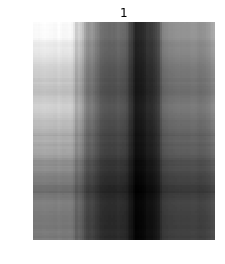

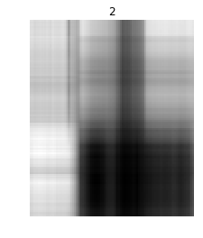

[figure not shown]

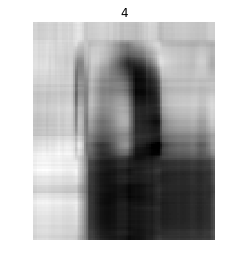

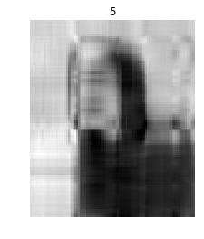

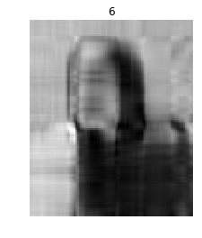

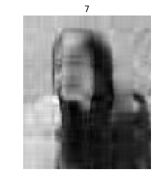

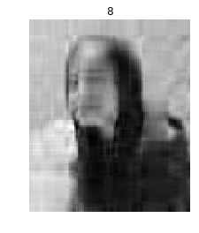

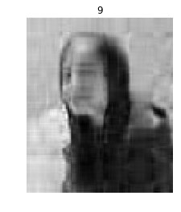

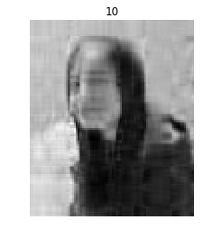

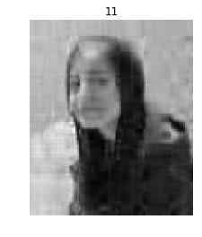

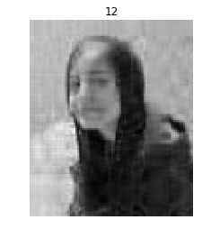

[88 more figures not shown]

```python
# To visualise every approximate matrix,
# values that are less than 0 are set to 0 and the values larger than 255 are set to 255.
def resetting(matrix):
    height, length = matrix.shape
    for i in range(height):
        for j in range(length):
            if matrix[i, j] < 0:
                matrix[i, j] = 0
            if matrix[i, j] > 255:
                matrix[i, j] = 255
    return matrix

# Approximation code here:
for i in range(1, 101):
    approximation = numpy.matrix(U[:, :i]) * D[:i,:i] * numpy.matrix(V[:i, :])
    resetting(approximation)
    pyplot.title(i)
    display_pgm(approximation)
```

**(c)** Finding the absolute approximation errors and the level of compression with respect to the original image for different values of ρ.

```python
# Finding the absolute error
def abs_error(U, D, V, A, i):
    approx = numpy.matrix(U[:, :i]) * D[:i,:i] * numpy.matrix(V[:i, :])
    return abs(A - approx)

# Outputting the main heading
print("ρ      ", "Max error     ", "Mean error     ", "Compression %")

# Image Dimensions
height = 120
width = 100

for p in range(1, 6):
    absoluteError = abs_error(U, D, V, image, p)
    max_val = absoluteError.max() # Calculating the maximum error from the absolute error array
    mean_val = absoluteError.mean() # Calculating the mean error from the absolute error array
    compression = (1 - (p * (1 + width + height) / 12000)) * 100 # Applying the compression formula (1 - k/12000)
    print(p,"      ",'{:.2f}'.format(max_val),"         ",'{:.2f}'.format(mean_val),"         ",'{:.1f}'.format(compression))

for p in range(10, 100, 10):
    absoluteError = abs_error(U, D, V, image, p)
    max_val = absoluteError.max()
    mean_val = absoluteError.mean()
    compression = (1 - (p * (1 + width + height) / 12000)) * 100
    print(p,"      ",'{:.2f}'.format(max_val),"         ",'{:.2f}'.format(mean_val),"         ",'{:.1f}'.format(compression))
```

```
ρ       Max error      Mean error      Compression %
1        130.67           40.10           98.2
2        119.43           19.90           96.3
3        122.01           14.88           94.5
4        119.91           13.01           92.6
5        114.91           11.78           90.8
10        93.46           8.27           81.6
20        58.72           5.55           63.2
30        33.27           4.03           44.8
40        22.71           2.86           26.3
50        15.39           2.02           7.9
60        14.29           1.38           -10.5
70        6.38           0.84           -28.9
80        3.38           0.43           -47.3
90        1.21           0.16           -65.8
```

**(c) Describe what negative values for compression correspond to and find the smallest value of ρ for which compression is negative:**  
Negative values of compression correspond to large ρ (singular values). The k value is dependent upon the image dimensions and the ρ used. The larger these values, the lower the compression percantage.  
ρ = 55, is the smallest value for which compression is negative.

**(d) Determining the most compressed approximation in terms of visual quality:**  
According to me visually, ρ = 51 is the most compressed approximation that is acceptable to me in terms of quality and clarity. It seemingly gets to the point where the quality of the image isn't compromised on anymore, and the larger the ρ values from this point onwards, the image clarity seems to look the same.  
**Corresponding compression:** 6.1%  
**Mean error:** 1.94